# Assignment4_Jia

## MATH 5472 Assignment 4

### Modified from one of my PhD students

## Problem 1

### (a)

$$p(P_i|y_i=0)=\text{Uniform}[0,1],\,p(P_i|y_i=1)=\text{Beta}(0.5,1),$$$$\Pr(y_i=0)=0.9,\,\Pr(y_i=1)=0.1.$$

Therefore, $$\text{fdr}(P)=\Pr(y=0|P)=\frac{p(P|y=0)\Pr(y=0)}{p(P|y=0)\Pr(y=0)+p(P|y=1)\Pr(y=1)}=\frac{0.9}{0.9+\frac{0.1}{2\sqrt{P}}}.$$

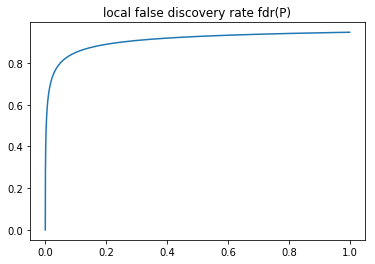

```python
import numpy as np
import matplotlib.pyplot as plt
P = np.linspace(0, 1, 20000)
fdr = 0.9 / (0.9 + 0.1 / 2 / np.sqrt(P+1e-10))
plt.figure(figsize=(6, 4))
plt.plot(P, fdr)
plt.title("local false discovery rate fdr(P)")
plt.show()
```

### (b) and (c)

```python
import numpy.random as npr
M = 20000
L = 1000
alpha = 0.1
n_BC = np.zeros(L)
n_BHP = np.zeros(L)
FDR_BHP = np.zeros(L)
indP = np.arange(M) + 1

for i in range(L):
    # Simulate P-values
    y = npr.binomial(1, 0.1, M)
    P = np.zeros(M)
    P[y==0] = npr.uniform(0, 1, np.sum(y==0))
    P[y==1] = npr.beta(0.5, 1, np.sum(y==1))

    # Bonferroni correction
    n_BC[i] = np.sum(P < (alpha/M))

    # Benjamini-Hochberg Procedure
    ind_sort = np.argsort(P)
    P_sort = P[ind_sort]
    y_sort = y[ind_sort]
    Lset = np.where((P_sort < (indP/M*alpha)) == True)[0]
    if (len(Lset) > 0):
        bh = Lset[-1] + 1
        n_BHP[i] = bh
        FDR_BHP[i] = np.sum(y_sort[:bh] == 0) / bh
```

```python
print("Average number of rejected null hypothesis:\n\tBC:%4f,\tBHP:%4f." % (np.mean(n_BC), np.mean(n_BHP)))
```

```
Average number of rejected null hypothesis:
	BC:4.542000,	BHP:26.004000.
```

```python
print("Global false discovery rate of BHP:\n\tmean=%4f,\tsd=%4f." % (np.mean(FDR_BHP), np.sqrt(np.var(FDR_BHP))))
```

```
Global false discovery rate of BHP:
	mean=0.091647,	sd=0.060933.
```

## Problem 2

### (a)

$$p(z_i|y_i=0)=\int p(z_i,\mu_i|y_i=0)d\mu_i=\int p(z_i|\mu_i,y_i=0)p(\mu_i|y_i=0)d\mu_i=\mathcal{N}(0.0,\sigma_0^2+1),$$$$p(z_i|y_i=1)=\int p(z_i,\mu_i|y_i=1)d\mu_i=\int p(z_i|\mu_i,y_i=1)p(\mu_i|y_i=1)d\mu_i=\mathcal{N}(2.5,\sigma_1^2+1),$$$$f(z)=p(z,y=0)+p(z,y=1)=\Pr(y=0)p(z|y=0)+\Pr(y=1)p(z|y=1)=0.95\mathcal{N}(0.0,1.5)+0.05\mathcal{N}(2.5,1.5).$$

### (b)

$$\text{fdr}(z)=\Pr(y=0|z)=\frac{\Pr(y=0)p(z|y=0)}{\Pr(y=0)p(z|y=0)+\Pr(y=1)p(z|y=1)}=\frac{0.95\mathcal{N}(0.0,1.5)}{0.95\mathcal{N}(0.0,1.5)+0.05\mathcal{N}(2.5,1.5)}.$$

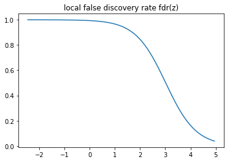

```python
from scipy.stats import norm
M = 20000
sd = np.sqrt(1.5)
lower = 0.0 - 2 * sd
upper = 2.5 + 2 * sd
z = np.linspace(lower, upper, M)
fdrz = 0.95*norm.pdf(z, 0.0, sd) / (0.95*norm.pdf(z, 0.0, sd) + 0.05*norm.pdf(z, 2.5, sd))
plt.figure(figsize=(6, 4))
plt.plot(z, fdrz)
plt.title("local false discovery rate fdr(z)")
plt.show()
```

Based on $f(z)$, we specify $z$ range in the plot to be $(0.0-2\sqrt{1.5}, 2.5+2\sqrt{1.5})$.

### (c)

Recall that in (a), we derive the marginal density of $z_i$ as $$f(z_i)=0.95\mathcal{N}(z_i|0.0,1.5)+0.05\mathcal{N}(z_i|2.5,1.5).$$ By Tweedie's formula, $$\begin{aligned}\mathbb{E}(\mu_i|z_i) &=z_i+\frac{d}{dz_i}\log f(z_i) \\ &=z_i+\frac{0.95\mathcal{N}(z_i|0.0,1.5)(-\frac{2z_i}{3})+0.05\mathcal{N}(z_i|2.5,1.5)(-\frac{2(z_i-2.5)}{3})}{f(z_i)} \\ &=\frac{0.95\mathcal{N}(z_i|0.0,1.5)z_i+0.05\mathcal{N}(z_i|2.5,1.5)(z_i+5)}{3f(z_i)}. \end{aligned}$$

## Problem 3

Observations are $z_i$, latent variables are $\mu_i$, parameter is $\alpha$. The complete-data likelihood is written as $$p(z,\mu|\alpha)=\prod_{i=1}^N\mathcal{N}(z_i|\mu_i,1)\mathcal{N}(\mu_i|0,\alpha^{-1}).$$ This implies the posterior distribution (E-step): $$p(\mu_i|z_i,\alpha)=\mathcal{N}(\nu_i,\sigma^2),$$ $$\sigma^2=\frac{1}{1+\alpha},\,\nu_i=z_i\sigma^2.$$ Then $Q$ function is obtained as $$Q(\alpha)=\mathbb{E}_{z|x,\alpha^{\text{old}}}\,(\log p(z,\mu|\alpha))=-N\log(2\pi)+\frac{N}{2}\log(\alpha)+\sum_{i=1}^N[-\frac{1+\alpha}{2}(\nu_i^2+\sigma^2)+z_i\nu_i-\frac12 z_i^2].$$ So the M-step updating equation is $$\alpha=\frac{N}{\sum_{i=1}^N(\nu_i^2+\sigma^2)}.$$ After EM algorithm converges, we obtain the estimate of $\mu$ by $$\hat{\mu_i}=\frac{z_i}{1+\hat{\alpha}}.$$

Note that EM is doing MLE while JSE uses the method of moments.

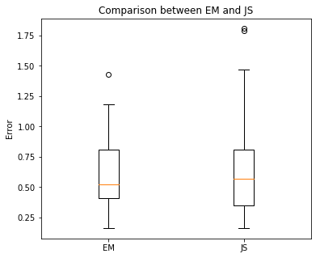

```
Comparison of MSE

JS:	mean=0.651009,	sd=0.398209.

EM:	mean=0.608507,	sd=0.299600.
```

```python
N = 5
alpha = 1
n_rep = 50
n_iter = 5000
tol = 1e-6
logls = np.zeros(n_iter+1)
err_em = np.zeros(n_rep)
err_js = np.zeros(n_rep)
for i in range(n_rep):
    # Simulate data
    mu = npr.normal(0, np.sqrt(1/alpha), N)
    z = mu + npr.normal(0, 1, N)

    # EM algorithm
    # initialize
    alpha_hat = 2
    logls[0] = - N/2*np.log(2*np.pi*(1+1/alpha_hat)) - 1/2/(1+1/alpha_hat) * np.sum(z**2) - 1e20
    # iterations
    for iter in range(n_iter):
        # E-step
        sigma_sq = 1 / (1 + alpha_hat)
        nu = z * sigma_sq
        # check log-likelihood
        logl = - N/2*np.log(2*np.pi*(1+1/alpha_hat)) - 1/2/(1+1/alpha_hat) * np.sum(z**2)
        logls[iter + 1] = logl
        imp = logls[iter + 1] - logls[iter]
        if (imp < 0):
            print("log-likelihood decreases...")
            break
        if (np.abs(imp / logls[iter]) < tol):
#             print("EM algorithm converges in %s iterations." % (iter+1))
            break
        # M-step
        alpha_hat = N / np.sum(nu**2 + sigma_sq)
    mu_hat_em = z / (1 + alpha_hat)
    err_em[i] = np.mean((mu_hat_em - mu) ** 2)

    # James-Stein estimator
    mu_hat_js = (1 - (N-2)/np.sum(z**2)) * z
    err_js[i] = np.mean((mu_hat_js - mu) ** 2)

# Visualization
plt.figure(figsize=(6, 5))
plt.boxplot([err_em, err_js], labels=["EM", "JS"])
plt.title("Comparison between EM and JS")
plt.ylabel("Error")
plt.show()
print("Comparison of MSE\n")
print("JS:\tmean=%4f,\tsd=%4f.\n" % (np.mean(err_js), np.std(err_js)))
print("EM:\tmean=%4f,\tsd=%4f.\n" % (np.mean(err_em), np.std(err_em)))
```

## Problem 4

### (a)

Based on the fact that $$p(\mu_i|y_i,\alpha)\propto p(\mu_i|\alpha)p(y_i|\mu_i),$$ we obtain the updating equation for E-step as $$p(\mu_i|y_i,\alpha)=\text{Dir}(\mu_i|\nu_i),\,\nu_{ik}=\alpha_k+y_{ik}.$$ Note that $$\mathbb{E}_{\mu_i|y_i}[\log(\mu_{ik})]=\psi(\nu_{ik})-\psi(\sum_{j=1}^K\nu_{ij}).$$ Then we obtain the $Q$ function as $$Q(\alpha)=\sum_{i=1}^n\left[\log\Gamma(\sum_{j=1}^K\alpha_j)-\sum_{k=1}^K\log\Gamma(\alpha_k)+\sum_{k=1}^K(\alpha_k-1)\log(\mu_{ik})+\log(\frac{N!}{y_{i1}!...y_{iK}!})+\sum_{k=1}^K y_{ik}\log(\mu_{ik})\right].$$ $$\frac{dQ}{d\alpha_k}=\sum_{i=1}^n\left[\psi(\sum_{j=1}^K\alpha_j)-\psi(\alpha_k)+\psi(\nu_{ik})-\psi(\sum_{j=1}^K\nu_{ij})\right]=N\left[\psi(\sum_{j=1}^K\alpha_j)-\psi(\alpha_k)\right]+\sum_{i=1}^N\left[\psi(\nu_{ik})-\psi(\sum_{j=1}^K\nu_{ij})\right].$$ Setting $\frac{dQ}{d\alpha_k}=0$ would not give closed-form updating approach for parameter $\alpha$, so we need to use iterative method in the M-step.

The MLE is a convex optimization problem. An easy way to see this is making use of the property of the exponential family. Recall that the exponential family of random variable $x$ is define as $$p(x|\eta)=h(x)\exp\{\eta^T T(x) - A(\eta)\},$$ where $\eta$ is called the natural parameter, and $T(x)$ is the sufficient statistics and $A(\eta)$ is the log normalizer. Some common distributions which belong to this family are the Gaussian, Bernoulli and Multinormial distributions. The Dirichlet distribution here again takes this form by writing: \begin{align*} h(x)&=1\\ \eta &= \alpha-1\\ T(x) &= \log p\\ A(\eta) & = N\left(\sum_k \log \Gamma(\alpha_k)- \log \Gamma\left(\sum_k \alpha_k\right)\right) \end{align*} An important property for the exponential family is that $A(\eta)$ is the cumulant generating function for the sufficient statistics. It means that $A'(\eta)$ is the expectation, and $A''(\eta)$ is the variance. Note that variance is always non-negative, implying $A(\eta)$ is convex and thus the log-likelihood is a convex function in $\eta$. An alternative way is evaluate the hessian matrix explicitly and show it is positive semi-definite.

### (b)

Let $\beta_k$ be the $k$-th column vector of the matrix $\beta$. Let $\alpha_{ik}=\exp(\beta_k^Tx_i)$.

E-step: $$p(\mu_i|y_i,x_i,\beta)\propto p(\mu_i|x_i,\beta)p(y_i|\mu_i),$$ implies the updating equation for the E-step as $$q(\mu_i)=\text{Dir}(\mu_i|(\nu_{i1},\nu_{i2},...,\nu_{iK})),$$ $$\nu_{ik}=y_{ik}+\exp(x_i^T\beta_k).$$

M-step: $$\begin{aligned}Q(\beta) &=\mathbb{E}_q\sum_i\left[\log(\frac{N!}{y_{i1}!...y_{iK}!})+\sum_k y_{ik}\log(\mu_{ik})+\log\Gamma(\sum_k e^{x_i^T\beta_k})-\sum_k\log\Gamma(e^{x_i^T\beta_k})+\sum_k(e^{x_i^T\beta_k}-1)\log(\mu_{ik})\right]\\ &=\sum_i\left[\log(\frac{N!}{y_{i1}!...y_{iK}!})+\log\Gamma(\sum_k e^{x_i^T\beta_k})-\sum_k\log\Gamma(e^{x_i^T\beta_k})+\sum_k(y_{ik}+e^{x_i^T\beta_k}-1)(\psi(\nu_{ik})-\psi(\sum_k\nu_{ik}))\right]. \end{aligned}$$ $$\frac{\partial Q}{\partial\beta_k}=\sum_i\left[\psi(\sum_k e^{x_i^T\beta_k})-\psi(e^{x_i^T\beta_k})+\psi(\nu_{ik})-\psi(\sum_k\nu_{ik})\right]e^{x_i^T\beta_k}x_i.$$ Setting $\frac{\partial Q}{\partial\beta_k}=0$ does not yield the closed-form solution, so we need to use iterative method in M-step. Here, we use Newton-Raphson method, the Hessian matrix is obtained as $$\frac{\partial^2 Q}{\partial\beta_k\partial\beta_k^T}=\sum_i\left[\psi'(\sum_ke^{x_i^T\beta_k})-\psi'(e^{x_i^T\beta_k})\right]e^{2x_i^T\beta_k}x_ix_i^T + \sum_i\left[\psi(\sum_ke^{x_i^T\beta_k})-\psi(e^{x_i^T\beta_k})+\psi(\nu_{ik})-\psi(\sum_k\nu_{ik})\right]e^{x_i^T\beta_k}x_ix_i^T.$$ The updating approach for M-step is given as $$\beta_k\leftarrow\beta_k-\left(\frac{\partial^2 Q}{\partial\beta_k\partial\beta_k^T}\right)^{-1}\frac{\partial Q}{\partial\beta_k}.$$

Lower bound: $$\mathcal{L}=\sum_i\left[\log(\frac{N!}{y_{i1}!...y_{iK}!})+\log\Gamma(\sum_k e^{x_i^T\beta_k})-\sum_k\log\Gamma(e^{x_i^T\beta_k})-\log\Gamma(\sum_k\nu_{ik})+\sum_k\log\Gamma(\nu_{ik})+\sum_k(y_{ik}+e^{x_i^T\beta_k}-\nu_{ik})(\psi(\nu_{ik})-\psi(\sum_k\nu_{ik}))\right].$$ At each iteration, after E-step and before M-step, $\mathcal{L}$ equals to the log-likelihood. So we check the monotonicity of the log-likelihood and convergence of EM algorithm by checking $\mathcal{L}$ at each iteration (after E-step and before M-step).

### (c)

```python
import pandas as pd
data = pd.read_csv('data.txt', sep=" ")
data.head()
```

|  | Y1 | Y2 | Y3 | Y4 | X1 | X2 | X3 | X4 | X5 |
| --- | --- | --- | --- | --- | --- | --- | --- | --- | --- |
| 0 | 24 | 17 | 5 | 4 | 0.287578 | 0.273623 | 0.159674 | 0.205827 | 0.304464 |
| 1 | 28 | 21 | 0 | 1 | 0.788305 | 0.593867 | 0.144516 | 0.942539 | 0.832819 |
| 2 | 14 | 24 | 0 | 12 | 0.408977 | 0.160185 | 0.149180 | 0.379324 | 0.593648 |
| 3 | 25 | 19 | 0 | 6 | 0.883017 | 0.853430 | 0.514434 | 0.626240 | 0.807197 |
| 4 | 13 | 13 | 5 | 19 | 0.940467 | 0.847739 | 0.492827 | 0.183502 | 0.294051 |

```python
# Load data
X = np.array(data[["X1","X2","X3","X4","X5"]])
Y = np.array(data[["Y1","Y2","Y3","Y4"]])
n = X.shape[0]
p = X.shape[1]
K = Y.shape[1]
N = np.sum(Y[0,:])
```

```python
from numpy.linalg import inv
from scipy.special import gammaln
from scipy.special import polygamma
#digamma polygamma(0, x); trigamma polygamma(1, x)

# Pre-specify
XXX = inv(X.T @ X) @ X.T
n_iter = 500
tol = 1e-6
lbs = np.zeros(n_iter)

# Initialization
beta = XXX @ np.log(Y + (Y==0))

# EM algorithm
for iter in range(n_iter):
    # E-step
    eXb = np.exp(X @ beta)
    V = Y + eXb
    # Lower bound
    lb = np.sum(
        gammaln(np.sum(eXb, axis=1)) - np.sum(gammaln(eXb), axis=1) - \
        gammaln(np.sum(V, axis=1)) + np.sum(gammaln(V), axis=1)
    )
    lbs[iter] = lb
    # M-step
    seXb = np.sum(eXb, axis=1)
    sV = np.sum(V, axis=1)
    for k in range(K):
        tmp1 = (polygamma(0, seXb) - polygamma(0, eXb[:,k]) + polygamma(0, V[:,k]) - polygamma(0, sV)) * eXb[:,k]
        tmp2 = (polygamma(1, seXb) - polygamma(1, eXb[:,k])) * (eXb[:,k] ** 2)
        f = tmp1.reshape((1,n)) @ X
        H = ((tmp1+tmp2) * X.T) @ X
        beta[:,k] = beta[:,k] - (inv(H) @ f.T)[:,0]
```

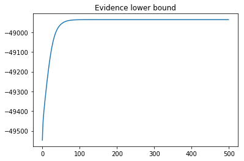

```python
plt.figure(figsize=(6, 4))
plt.plot(np.arange(n_iter), lbs)
plt.title("Evidence lower bound")
plt.show()
```

```python
print("beta estimate=\n", beta)
```

```
beta estimate=
 [[-0.13024684 -0.14688106 -0.08145525 -0.08683236]
 [ 0.0465073   0.15911102  0.15572079  0.02770318]
 [ 1.31197343  1.02830778 -0.4280816   0.08140173]
 [ 1.11371315  0.94910088 -0.7092562   0.04612451]
 [ 1.21853026  0.96546416 -0.80650035 -0.07232636]]
```